# latihan 6

# Library

```r
library(ggplot2)
library(tsibble)
library(tseries)
library(MASS)
library(forecast)
library(TSA)
library(TTR)
library(aTSA)
library(graphics)
library(readxl)
```

# Data

```r
dt <- read_xlsx("~/Kuliah/Semester 5/MPDW/MPDW Separated.xlsx")
dt.ts<-ts(dt)
```

## Eksplorasi Data

### Plot Data Penuh

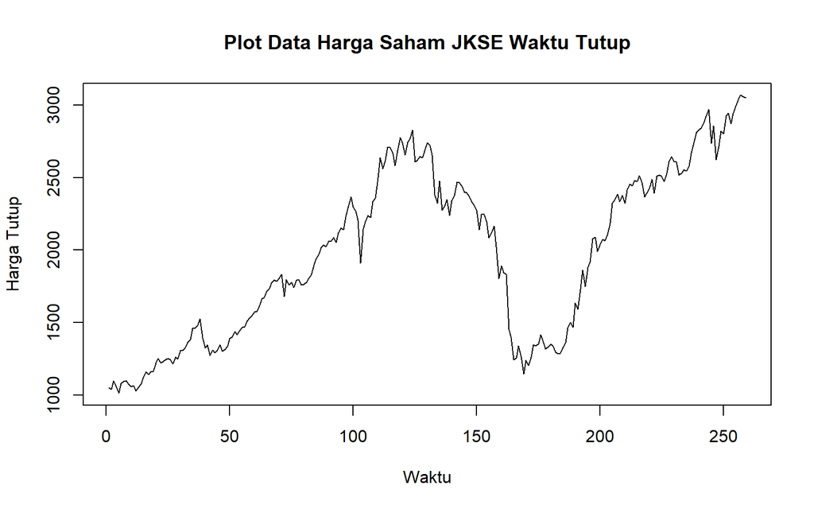

```r
plot.ts(dt.ts[,"Close"], lty=1, xlab="Waktu", ylab="Harga Tutup",
        main="Plot Data Harga Saham JKSE Waktu Tutup")
```

Berdasarkan plot data deret waktu, terlihat bahwa data cenderung memiliki trend fluktuatif dari naik ke turun dan kembali naik. Berdasarkan pola data, pembagian data latih dan data uji ditetapkan dengan proporsi 87%:13%.

### Plot Data Latih

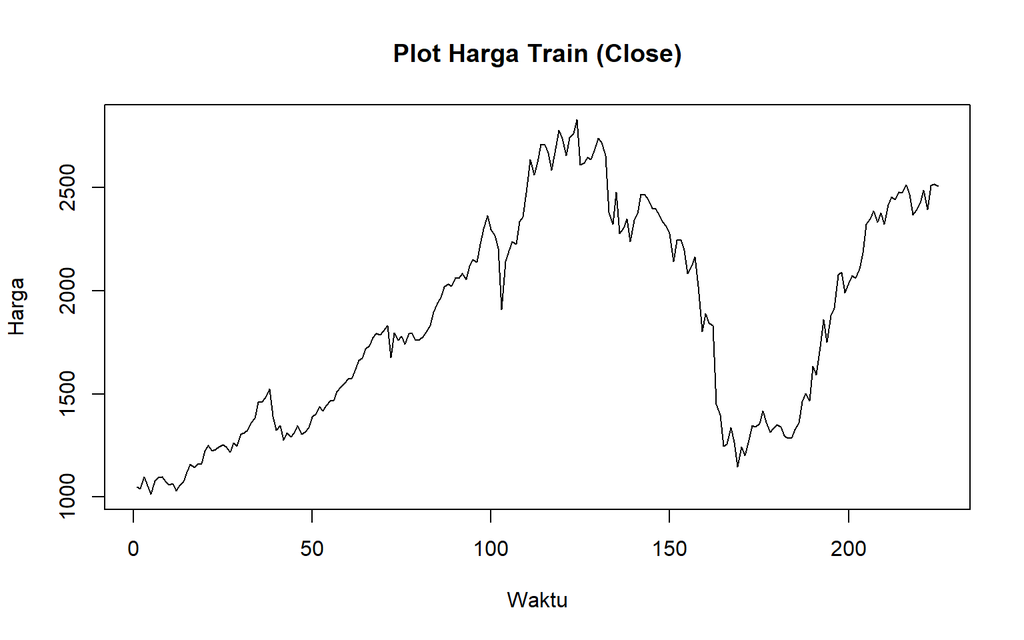

```r
# ambil hanya kolom harga (misalnya "Close")
dtclose <- dt.ts[,"Close"]

# bagi train set sesuai indeks
dttrain <- dtclose[1:225]
train.ts <- ts(dttrain)

# plot ulang
plot.ts(train.ts, lty=1, xlab="Waktu", ylab="Harga",
        main="Plot Harga Train (Close)")
```

Berdasarkan plot data deret waktu pada data latih, terlihat bahwa data cenderung memiliki trend fluktuatif dan tidak bergerak pada nilai tengah tertentu. Hal ini mengindikasikan bahwa data tidak stasioner dalam rataan.

### Plot Data Uji

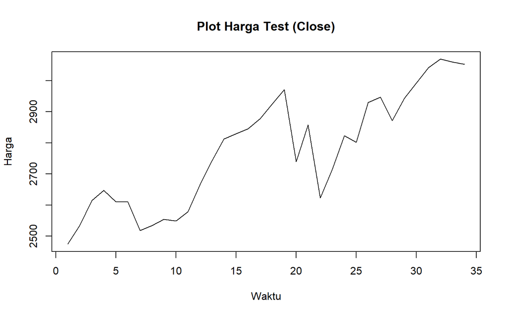

```r
dttest <- dtclose[226:259]
test.ts <- ts(dttest)
plot.ts(test.ts, lty=1, xlab="Waktu", ylab="Harga",
        main="Plot Harga Test (Close)")
```

# Uji Stasioneritas Data

## Plot ACF

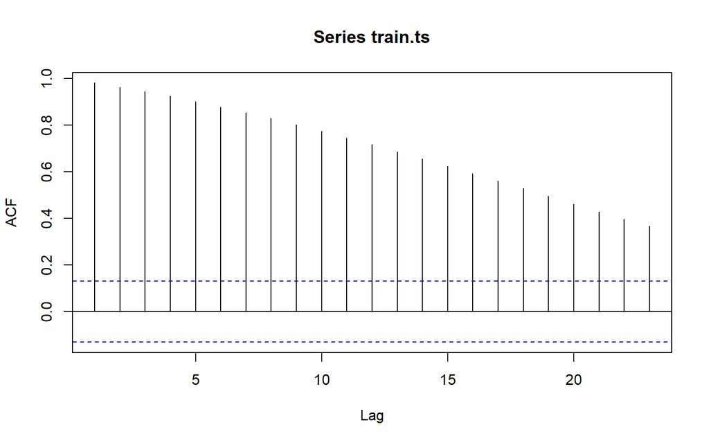

```r
acf(train.ts)
```

Berdasarkan plot ACF, terlihat bahwa plot ACF pada data tersebut menurun secara perlahan (*tails off slowly*) yang menandakan data tidak stasioner dalam rataan

## Uji ADF

$H_0$ : Data tidak stasioner dalam rataan $H_1$ : Data stasioner dalam rataan

```r
tseries::adf.test(train.ts)
```

```
##
##  Augmented Dickey-Fuller Test
##
## data:  train.ts
## Dickey-Fuller = -1.7786, Lag order = 6, p-value = 0.6689
## alternative hypothesis: stationary
```

## Plot Box-Cox

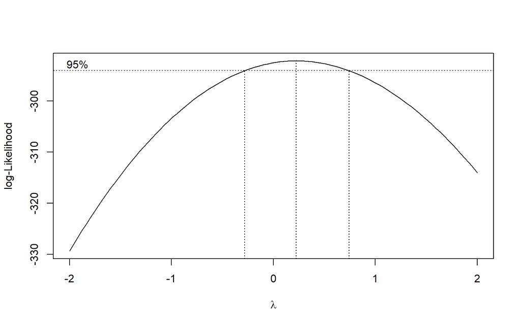

```r
index <- seq(1:225)
bc = boxcox(train.ts~index, lambda = seq(-2,2,by=1))
```

```r
lambda <- bc$x[which.max(bc$y)]
lambda
```

```
## [1] 0.2222222
```

```r
# Selang kepercayaan 95% untuk lambda
ci_lambda <- bc$x[bc$y > max(bc$y) - 0.5 * qchisq(0.95, 1)]

# Batas bawah dan batas atas
ci_lower <- min(ci_lambda)
ci_upper <- max(ci_lambda)

c(Batas_Bawah = ci_lower, Batas_Atas = ci_upper)
```

```
## Batas_Bawah  Batas_Atas
##  -0.2626263   0.7070707
```

Gambar di atas menunjukkan nilai λ optimum (rounded value) sebesar 0.222222 dan selang kepercayaan 95% nilai memiliki batas bawah -0.2626263 dan batas atas 0.7070707. Selang tersebut tidak memuat nilai satu sehingga dapat dikatakan bahwa data tidak stasioner dalam ragam.

# Penanganan Ketidakstasioneran Data

## Differencing 1

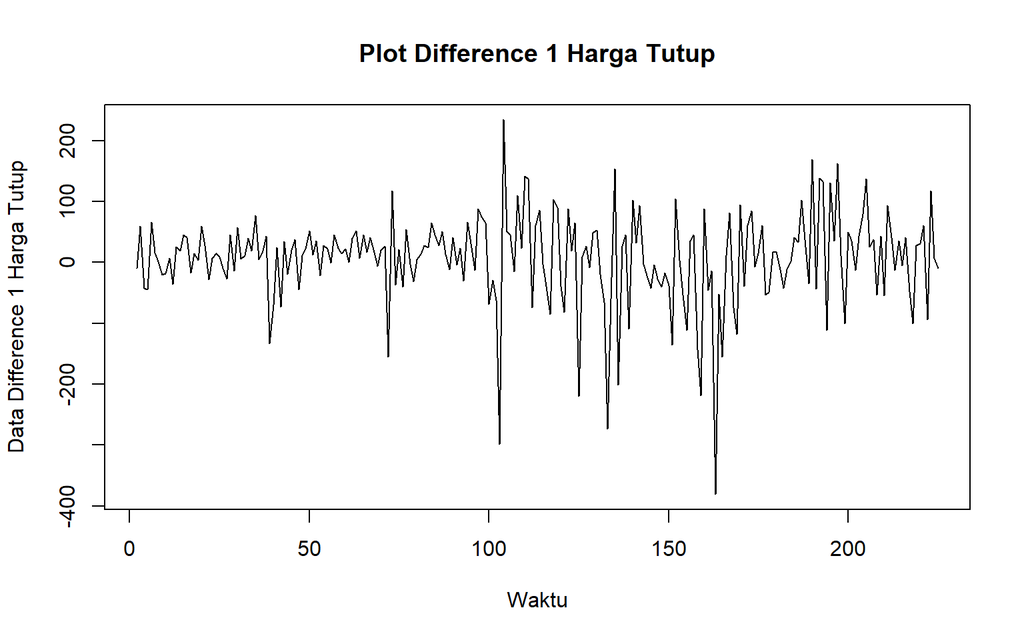

```r
train.diff <- diff(train.ts,differences = 1)
plot.ts(train.diff, lty=1, xlab="Waktu", ylab="Data Difference 1 Harga Tutup", main="Plot Difference 1 Harga Tutup")
```

### Plot ACF

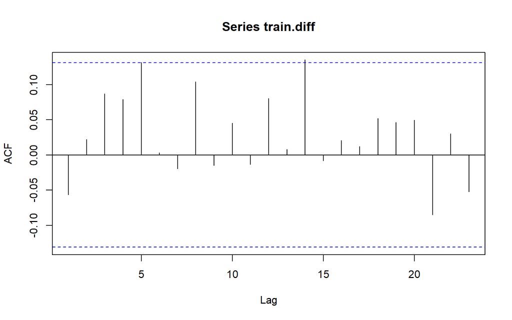

```r
acf(train.diff)
```

Berdasarkan plot tersebut, terlihat bahwa plot ACF sudah tails off secara normal (tidak slowly). Hal ini menandakan data sudah stasioner dalam rataan dan ketidakstasioneran data telah berhasil tertangani.

### Uji ADF

```r
tseries::adf.test(train.diff)
```

```
##
##  Augmented Dickey-Fuller Test
##
## data:  train.diff
## Dickey-Fuller = -4.5698, Lag order = 6, p-value = 0.01
## alternative hypothesis: stationary
```

Berdasarkan uji ADF tersebut, didapat p-value sebesar 0.01 yang lebih kecil dari taraf nyata 5% sehingga tolak dan menandakan bahwa data sudah stasioner dalam rataan. Hal ini sesuai dengan hasil eksplorasi menggunakan plot time series dan plot ACF.

### Plot Box-Cox

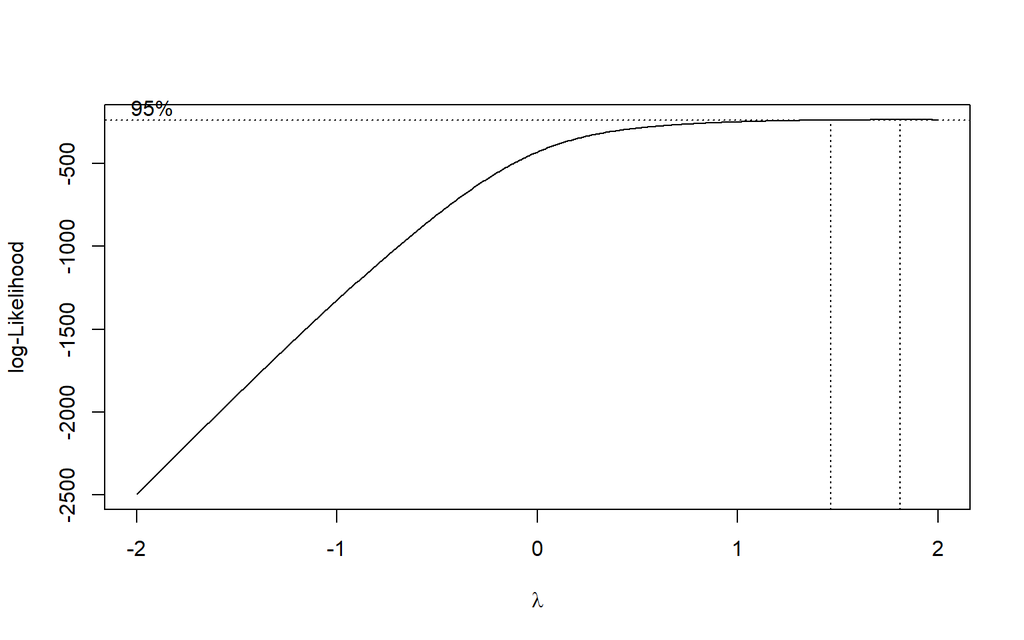

```r
train_shift <- train.diff - min (train.diff) + 1
index <- seq_along(train_shift)
bc = boxcox(train_shift~index, lambda = seq(-2,2,by=0.01))
```

```r
#Nilai Rounded Lambda
lambda <- bc$x[which.max(bc$y)]
lambda
```

```
## [1] 1.81
```

```r
#SK
bc$x[bc$y > max(bc$y) - 1/2 * qchisq(.95,1)]
```

```
##  [1] 1.47 1.48 1.49 1.50 1.51 1.52 1.53 1.54 1.55 1.56 1.57 1.58 1.59 1.60 1.61
## [16] 1.62 1.63 1.64 1.65 1.66 1.67 1.68 1.69 1.70 1.71 1.72 1.73 1.74 1.75 1.76
## [31] 1.77 1.78 1.79 1.80 1.81 1.82 1.83 1.84 1.85 1.86 1.87 1.88 1.89 1.90 1.91
## [46] 1.92 1.93 1.94 1.95 1.96 1.97 1.98 1.99 2.00
```

## Differencing 2

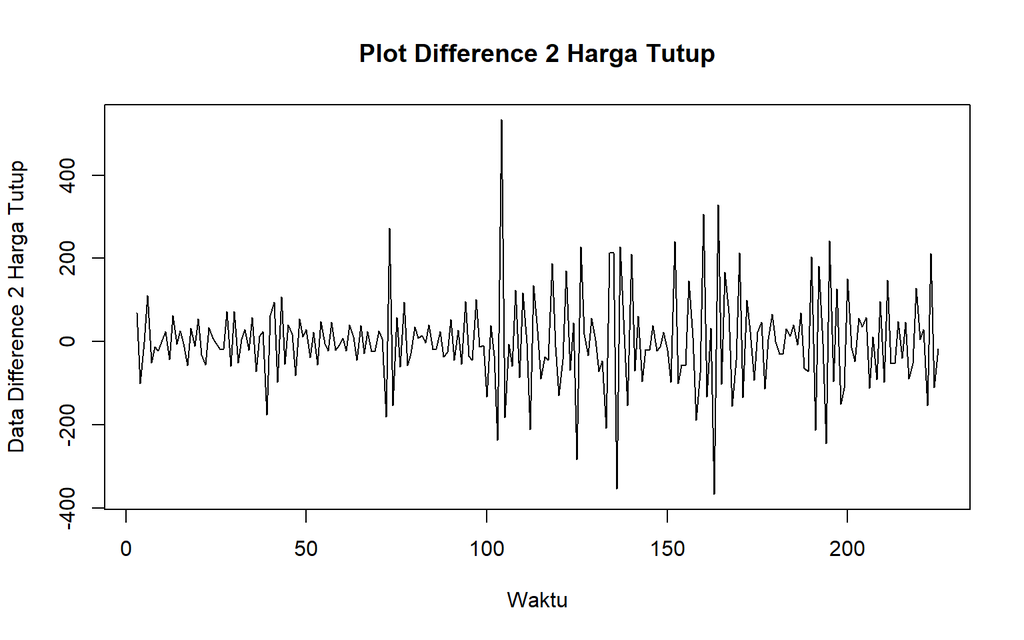

```r
train.diff2 <- diff(train.diff,differences = 1)
plot.ts(train.diff2, lty=1, xlab="Waktu", ylab="Data Difference 2 Harga Tutup", main="Plot Difference 2 Harga Tutup")
```

Berdasarkan plot data deret waktu, terlihat bahwa data sudah stasioner dalam rataan ditandai dengan data bergerak pada nilai tengah tertentu (tidak terdapat trend ataupun musiman pada data)

### Plot ACF

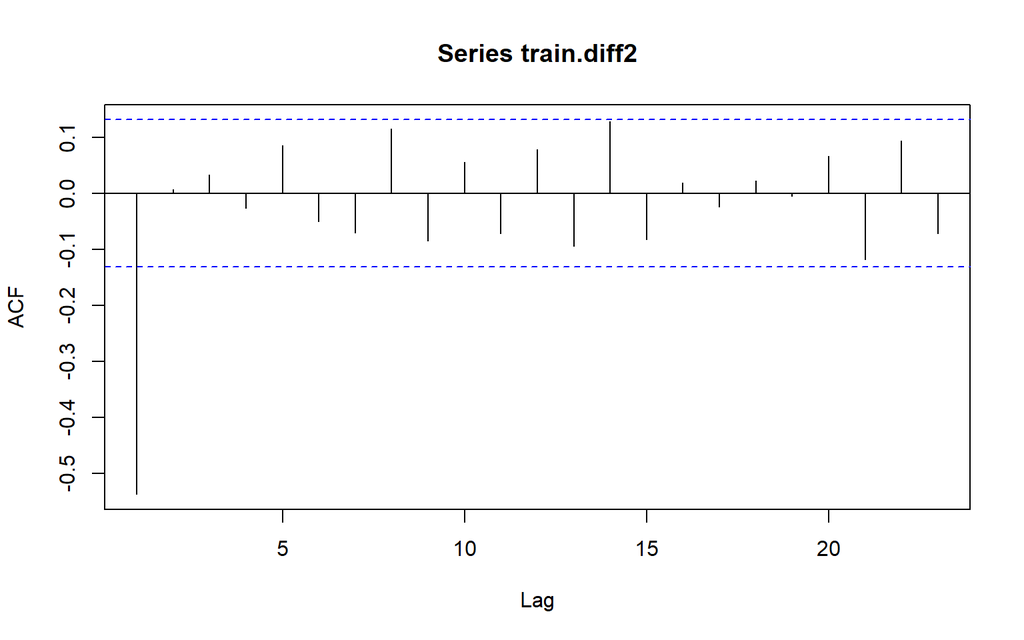

```r
acf(train.diff2)
```

Berdasarkan plot tersebut, terlihat bahwa plot ACF sudah tails off secara normal (tidak slowly). Hal ini menandakan data sudah stasioner dalam rataan dan ketidakstasioneran data telah berhasil tertangani.

### Uji ADF

```r
tseries::adf.test(train.diff2)
```

```
##
##  Augmented Dickey-Fuller Test
##
## data:  train.diff2
## Dickey-Fuller = -9.1812, Lag order = 6, p-value = 0.01
## alternative hypothesis: stationary
```

Berdasarkan uji ADF tersebut, didapat p-value sebesar 0.01 yang lebih kecil dari taraf nyata 5% sehingga tolak dan menandakan bahwa data sudah stasioner dalam rataan. Hal ini sesuai dengan hasil eksplorasi menggunakan plot time series dan plot ACF.

### Plot Box-Cox

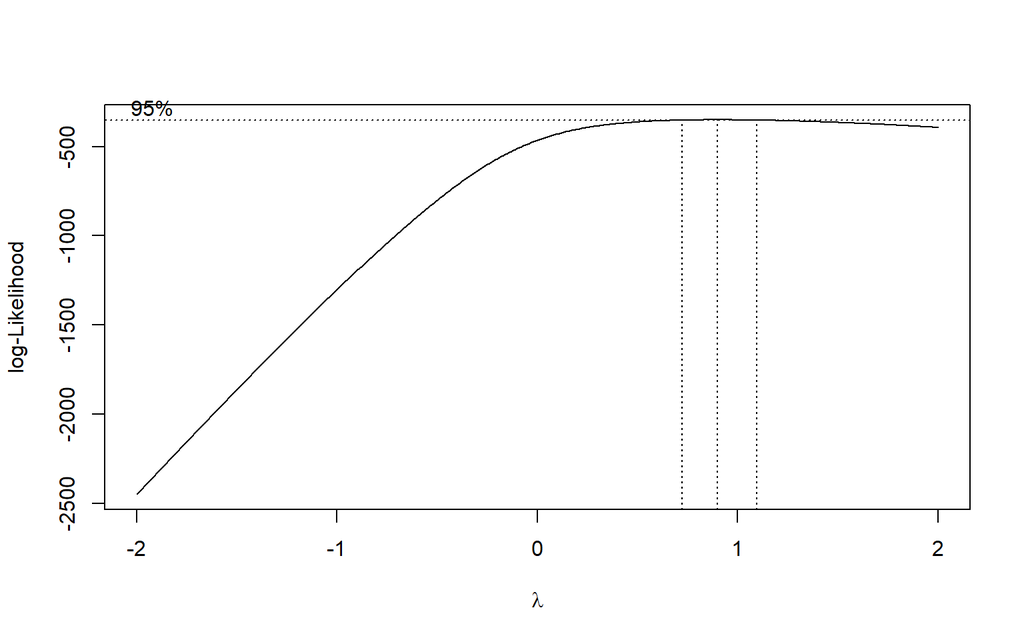

```r
train_shift2 <- train.diff2 - min (train.diff2) + 1
index <- seq_along(train_shift2)
bc2 = boxcox(train_shift2~index, lambda = seq(-2,2,by=0.01))
```

```r
#Nilai Rounded Lambda
lambda2 <- bc2$x[which.max(bc2$y)]
lambda2
```

```
## [1] 0.9
```

```r
#SK
bc2$x[bc2$y > max(bc2$y) - 1/2 * qchisq(.95,1)]
```

```
##  [1] 0.73 0.74 0.75 0.76 0.77 0.78 0.79 0.80 0.81 0.82 0.83 0.84 0.85 0.86 0.87
## [16] 0.88 0.89 0.90 0.91 0.92 0.93 0.94 0.95 0.96 0.97 0.98 0.99 1.00 1.01 1.02
## [31] 1.03 1.04 1.05 1.06 1.07 1.08 1.09
```

Gambar di atas menunjukkan nilai λ optimum (rounded value) sebesar 0.9 dan selang kepercayaan 95% nilai memiliki batas bawah 0.73 dan batas atas 1.09. Selang tersebut memuat nilai satu sehingga dapat dikatakan bahwa data sudah stasioner dalam ragam.

# Identifikasi Model

## Plot ACF

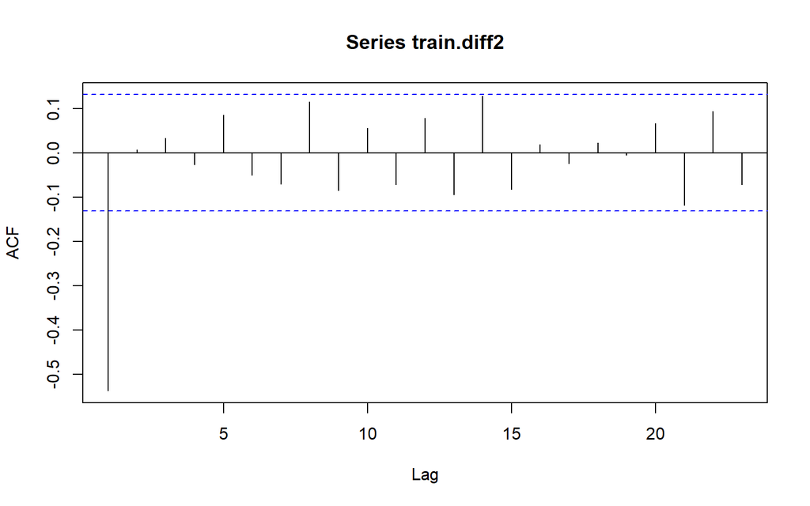

```r
acf(train.diff2)
```

## Plot PACF

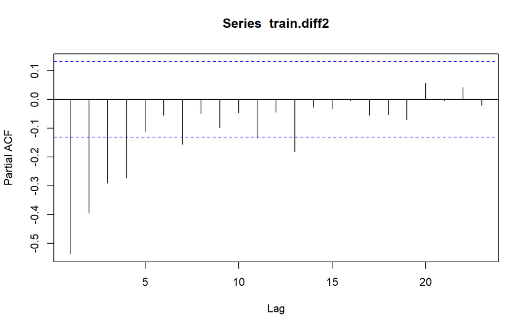

```r
pacf(train.diff2)
```

Berdasarkan plot tersebut, terlihat bahwa plot PACF cenderung *tails off*. Jika baik plot ACF maupun plot PACF keduanya dianggap tails of, maka model yang terbentuk adalah ARIMA(1,2,1)

## Plot EACF

```r
eacf(train.diff2)
```

```
## AR/MA
##   0 1 2 3 4 5 6 7 8 9 10 11 12 13
## 0 x o o o o o o o o o o  o  o  o
## 1 x o o o o o o o o o o  o  o  o
## 2 x x x o o o o o o o o  o  o  o
## 3 x x x o o o o o o o o  o  o  o
## 4 x o x o x o o o o o o  o  o  o
## 5 x o x o x x o o o o o  o  o  o
## 6 x x x o x o o o o o o  o  o  o
## 7 x x o o x o o o o o o  o  o  o
```

Identifikasi model menggunakan plot EACF dilakukan dengan melihat ujung segitiga pada pola segitiga nol. Dalam hal ini model tentatif yang terbentuk adalah ARIMA(0,2,1), ARIMA(0,2,2), ARIMA(1,2,2), ARIMA(2,2,4), dan ARIMA(0,2,3).

# Pendugaan Parameter Model Tentatif

## ARIMA(0,2,1)

```r
model1.da=Arima(train.ts, order=c(0,2,1),method="ML")
summary(model1.da)
```

```
## Series: train.ts
## ARIMA(0,2,1)
##
## Coefficients:
##           ma1
##       -0.9496
## s.e.   0.0290
##
## sigma^2 = 5844:  log likelihood = -1284.13
## AIC=2572.27   AICc=2572.32   BIC=2579.08
##
## Training set error measures:
##                    ME     RMSE      MAE        MPE     MAPE      MASE
## Training set 0.930743 75.93249 52.17555 0.09801152 2.877722 0.9713055
##                    ACF1
## Training set -0.1020518
```

```r
lmtest::coeftest(model1.da)
```

```
##
## z test of coefficients:
##
##      Estimate Std. Error z value  Pr(>|z|)
## ma1 -0.949649   0.029007 -32.739 < 2.2e-16 ***
## ---
## Signif. codes:  0 '***' 0.001 '**' 0.01 '*' 0.05 '.' 0.1 ' ' 1
```

## ARIMA(0,2,2)

```r
model2.da=Arima(train.ts, order=c(0,2,2),method="ML")
summary(model2.da)
```

```
## Series: train.ts
## ARIMA(0,2,2)
##
## Coefficients:
##           ma1     ma2
##       -1.0556  0.1237
## s.e.   0.0680  0.0709
##
## sigma^2 = 5798:  log likelihood = -1282.68
## AIC=2571.36   AICc=2571.47   BIC=2581.58
##
## Training set error measures:
##                     ME     RMSE      MAE       MPE     MAPE      MASE
## Training set 0.6977291 75.46376 51.81876 0.1036874 2.862992 0.9646635
##                       ACF1
## Training set -0.0004060512
```

```r
lmtest::coeftest(model2.da)
```

```
##
## z test of coefficients:
##
##      Estimate Std. Error  z value Pr(>|z|)
## ma1 -1.055592   0.067974 -15.5293  < 2e-16 ***
## ma2  0.123711   0.070923   1.7443  0.08111 .
## ---
## Signif. codes:  0 '***' 0.001 '**' 0.01 '*' 0.05 '.' 0.1 ' ' 1
```

## ARIMA(1,2,1)

```r
model3.da=Arima(train.ts, order=c(1,2,1),method="ML")
summary(model3.da)
```

```
## Series: train.ts
## ARIMA(1,2,1)
##
## Coefficients:
##           ar1      ma1
##       -0.1184  -0.9280
## s.e.   0.0722   0.0336
##
## sigma^2 = 5804:  log likelihood = -1282.82
## AIC=2571.64   AICc=2571.74   BIC=2581.86
##
## Training set error measures:
##                     ME     RMSE      MAE       MPE     MAPE      MASE
## Training set 0.7449778 75.50645 51.89761 0.1031374 2.865897 0.9661314
##                      ACF1
## Training set -0.009809043
```

```r
lmtest::coeftest(model3.da)
```

```
##
## z test of coefficients:
##
##      Estimate Std. Error  z value Pr(>|z|)
## ar1 -0.118377   0.072183  -1.6399    0.101
## ma1 -0.927952   0.033591 -27.6252   <2e-16 ***
## ---
## Signif. codes:  0 '***' 0.001 '**' 0.01 '*' 0.05 '.' 0.1 ' ' 1
```

## ARIMA(1,2,2)

```r
model4.da=Arima(train.ts, order=c(1,2,2),method="ML")
summary(model4.da)
```

```
## Series: train.ts
## ARIMA(1,2,2)
##
## Coefficients:
##          ar1      ma1     ma2
##       0.1134  -1.1664  0.2289
## s.e.  0.3606   0.3505  0.3323
##
## sigma^2 = 5822:  log likelihood = -1282.63
## AIC=2573.25   AICc=2573.44   BIC=2586.88
##
## Training set error measures:
##                     ME     RMSE      MAE       MPE     MAPE      MASE
## Training set 0.6687779 75.44908 51.75851 0.1039747 2.860766 0.9635417
##                      ACF1
## Training set -0.002214209
```

```r
lmtest::coeftest(model4.da)
```

```
##
## z test of coefficients:
##
##     Estimate Std. Error z value  Pr(>|z|)
## ar1  0.11339    0.36056  0.3145 0.7531478
## ma1 -1.16638    0.35053 -3.3274 0.0008765 ***
## ma2  0.22889    0.33233  0.6887 0.4909867
## ---
## Signif. codes:  0 '***' 0.001 '**' 0.01 '*' 0.05 '.' 0.1 ' ' 1
```

## ARIMA(2,2,4)

```r
model5.da=Arima(train.ts, order=c(2,2,4),method="ML")
summary(model5.da)
```

```
## Series: train.ts
## ARIMA(2,2,4)
##
## Coefficients:
##          ar1     ar2      ma1     ma2     ma3      ma4
##       0.4317  0.4444  -1.5071  0.1140  0.5144  -0.1214
## s.e.  0.5410  0.5228   0.5382  1.0677  0.5860   0.0801
##
## sigma^2 = 5749:  log likelihood = -1280.84
## AIC=2575.69   AICc=2576.21   BIC=2599.54
##
## Training set error measures:
##                      ME     RMSE      MAE         MPE     MAPE      MASE
## Training set -0.3557363 74.46084 51.11509 -0.01251887 2.811472 0.9515639
##                      ACF1
## Training set -0.003686344
```

```r
lmtest::coeftest(model5.da)
```

```
##
## z test of coefficients:
##
##      Estimate Std. Error z value Pr(>|z|)
## ar1  0.431748   0.541045  0.7980  0.42488
## ar2  0.444393   0.522843  0.8500  0.39535
## ma1 -1.507097   0.538240 -2.8000  0.00511 **
## ma2  0.114050   1.067680  0.1068  0.91493
## ma3  0.514420   0.586027  0.8778  0.38005
## ma4 -0.121355   0.080063 -1.5157  0.12958
## ---
## Signif. codes:  0 '***' 0.001 '**' 0.01 '*' 0.05 '.' 0.1 ' ' 1
```

## ARIMA(0,2,3)

```r
model6.da=Arima(train.ts, order=c(0,2,3),method="ML")
summary(model6.da)
```

```
## Series: train.ts
## ARIMA(0,2,3)
##
## Coefficients:
##           ma1     ma2     ma3
##       -1.0491  0.0927  0.0287
## s.e.   0.0676  0.0989  0.0655
##
## sigma^2 = 5820:  log likelihood = -1282.58
## AIC=2573.17   AICc=2573.35   BIC=2586.8
##
## Training set error measures:
##                     ME     RMSE      MAE       MPE     MAPE      MASE
## Training set 0.6512313 75.43616 51.68891 0.1043167 2.858088 0.9622461
##                      ACF1
## Training set -0.005450544
```

```r
lmtest::coeftest(model6.da)
```

```
##
## z test of coefficients:
##
##      Estimate Std. Error  z value Pr(>|z|)
## ma1 -1.049101   0.067576 -15.5248   <2e-16 ***
## ma2  0.092673   0.098858   0.9374   0.3485
## ma3  0.028678   0.065500   0.4378   0.6615
## ---
## Signif. codes:  0 '***' 0.001 '**' 0.01 '*' 0.05 '.' 0.1 ' ' 1
```